# Network Science Final Paper

- Show All Code
- Hide All Code
- View Source

Author

Jonas Kreutzer

Published

June 13, 2023

This course paper explores some features of the Swedish Forest Bioeconomy Innovation System. The forestry sector is one of the most important sectors in Sweden. It is also grounds for contested debates about the future of sustainable forestry, as the expectations placed upon it increase due to an emerging bioeconomy (Högbom et al., 2021). The debate centers around the question what kind of bioeconomy vision the forestry sector aims to realize. This discourse is dominated by the bioresource vision (Holmgren et al., 2022), a future plan for the forest which has been summarized as “more of everything”, as it promises to incorporate more biodiversity, more carbon sequestration with more economic return (Beland Lindahl et al., 2015). Promises which might be difficult to keep (Högbom et al., 2021). All visions of a sustainable bioeconomy rely on innovation. Some, like the bioresource and biotechnology vision, more explicitly than others (Bugge et al., 2016).

A digital version of this paper including the annotated code can be found at https://pjkreutzer.github.io/network-course-paper.

## Questions

Some questions that should eventually be answered are:

How well connected is the network? Is it largely sparse, with few communities? Is it almost fully connected? Does it have a giant component?

Does the network have one or several hubs, around which the nodes are centered? Who are they, and where?

What explains the structure? Sectors? Geography?

# Data

**Load libraries**

```r
library(here)
library(rio)
# remotes::install_github("pjkreutzer/swinnotools")
# library(swinnotools)
library(tidyverse)
library(igraph)
library(tidygraph)
library(ggraph)
library(scales)
library(gt)
```

**Set up custom figure theme**

```r
library(ggthemes)
library(showtext)

showtext_auto()
font_add_google("Space Grotesk", regular = "400")
font_add_google("Inconsolata", regular = "400")


pjk_theme <- function() {
    font <- "Inconsolata"
    base_theme <- theme_classic()

    modified_theme <- base_theme +
        theme(
            text = element_text(family = font)
        )
}

darkgreen <- "#051f20"
phtahlogreen <- "#0b2b26"
mediumjunglegreen <- "#163832"
brunswickgreen <- "#235347"
darkseagreen <- "#8eb69b"
chinesewhite <- "#daf1de"
```

**Load and Clean Data**

```r
swinno <- import(here("assignments", "final", "data", "modified-data", "swinno.csv"))

vision_sinno_id <- import(here("assignments", "final", "data", "modified-data", "bioeconomy_visions.csv"))

collaborations <- import(here("assignments", "data", "raw-data", "collaboration_data.xlsx")) |>
    janitor::clean_names()

value_columns <- c(
    "biotechnology", "bioresources", "bioecology", "not_bioeconomy",
    "unsure", "total_innovation_count"
)

total_innovation_count <- import(here("assignments/final/data/modified-data/total_innovation_count.csv")) |>
    tidyr::separate(col = "firm", into = c("firm_1", "firm", "firm_id"), sep = ";") |>
    mutate(firm = str_trim(firm)) |>
    select(-c("firm_1", "firm_id")) |>
    drop_na() |>
    group_by(firm) |>
    summarise(total_innovation_count = sum(total_innovation_count)) |>
    ungroup()

firm_innovation_experience <- import(here("assignments", "final", "data", "modified-data", "bioeconomy_vision_shares.csv"))

total_innovation_count_filtered <- total_innovation_count |>
    filter(!firm %in% firm_innovation_experience$firm) |>
    mutate(
        biotechnology = NA,
        bioresources = NA,
        bioecology = NA,
        not_bioeconomy = NA,
        unsure = NA,
        share_biotechnology = NA,
        share_bioresources = NA,
        share_bioecology = NA,
        share_not_bioeconomy = NA,
        share_unsure = NA
    )

firm_innovation_experience_merged <- rbind(total_innovation_count_filtered, firm_innovation_experience)

forest_collaborations <- collaborations |>
    filter(sinno_id %in% swinno$sinno_id)

select_collaborators <- function(dataframe, id_col = "sinno_id", collaborators) {
    collab_subset <- dataframe[, c(id_col, collaborators)]

    return(collab_subset)
}

combinations <- function(x) {
    cbind(x[1], as.data.frame(t(combn(x[-1], 2))))
}

combine_collaborators <- function(dataframe, id_col, collaborators) {
    subset <- select_collaborators(dataframe, id_col, collaborators)

    collab_pairs <- do.call(rbind, apply(subset, 1, combinations))
    names(collab_pairs) <- c("id", "firm_1", "firm_2")

    cleaned_pairs <- subset(collab_pairs, collab_pairs$"firm_1" != 0)
    cleaned_pairs <- subset(collab_pairs, collab_pairs$"firm_2" != 0)

    # TODO: filter for unique
    # TODO: filter out unknowns
    # TODO: make id col optional as input
}

edge_list <- combine_collaborators(forest_collaborations,
    id_col = "sinno_id",
    collaborators = c(
        "firm_level_2",
        "collaborator_1",
        "collaborator_2",
        "collaborator_3",
        "collaborator_4",
        "collaborator_5",
        "collaborator_6"
    )
)
```

The data for this paper is based on the Swedish Innovation Database (SWINNO) (Sjöö et al., 2014). SWINNO has been used previously for research on the Swedish innovation network, for example by Taalbi (2017). In the most recent release the database contains just below 5000 innovation from 1971 to 2021.

# Network

**Set up network in igraph**

```r
cleaned_edge_list <- edge_list |> filter(firm_1 != "
[Unknown]" & firm_2 !=
    "[Unknown]")

node_attributes <- firm_innovation_experience_merged |>
    select(c(
        "firm",
        "biotechnology",
        "bioresources",
        "bioecology",
        "not_bioeconomy",
        "unsure",
        "total_innovation_count",
        "share_biotechnology",
        "share_bioresources",
        "share_bioecology",
        "share_unsure",
        "share_not_bioeconomy"
    ))

g <- graph_from_data_frame(edge_list[, c("firm_1", "firm_2")], directed = FALSE)

missing_vertices <- setdiff(unique(c(cleaned_edge_list$firm_1, cleaned_edge_list$firm_2)), firm_innovation_experience_merged$firm)

missing_data <- data.frame(
    firm = missing_vertices, biotechnology = NA,
    bioresources = NA,
    bioecology = NA,
    not_bioeconomy = NA,
    unsure = NA,
    share_biotechnology = NA,
    share_bioresources = NA,
    share_bioecology = NA,
    share_not_bioeconomy = NA,
    share_unsure = NA,
    total_innovation_count = NA
)

vertex_data <- rbind(firm_innovation_experience_merged, missing_data)

cleaned_g <- graph_from_data_frame(cleaned_edge_list[, c("firm_1", "firm_2")], directed = FALSE, vertices = vertex_data)


# the created igraph graph objects include nodes of degree 0 because the dataframe holding node attributes contains firms that have not collaborated with other companies.
```

There are 550 links between 932 node from 855 innovations. In the network, each node is an innovating firm and a link represents a collaboration on at least one innovation with another firm.

**Plot Network**

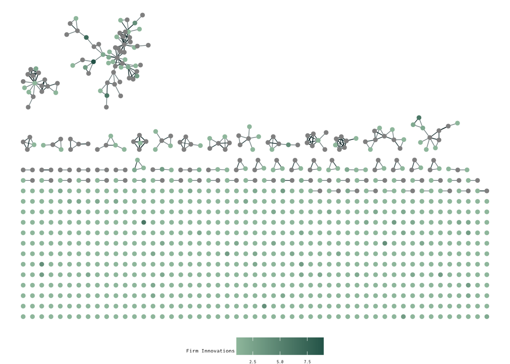

Figure 1: Network Plot - Stress Layout

```r
as_tbl_graph(cleaned_g) |>
    create_layout(layout = "stress") |>
    ggraph() +
    geom_edge_link(color = darkgreen, alpha = 0.6, width = 0.3) +
    geom_node_point(aes(color = total_innovation_count)) +
    scale_color_gradient(low = darkseagreen, high = brunswickgreen) +
    labs(color = "Firm Innovations") +
    theme_void() +
    theme(text = element_text(family = "Inconsolata"), legend.position = "bottom", legend.justification = "center")
# connect to use sectors
#
```

## Basic Descriptive Statistics

**Calculate Average Path And Diameter**

```r
avg_path_length <- average.path.length(cleaned_g)
diameter <- diameter(cleaned_g)
```

**Check if Network is Connected**

```r
components <- clusters(cleaned_g)

n_clusters <- components$no

if (is_connected(cleaned_g)) {
    message <- glue::glue("The network is fully connected with average path length", avg_path_length, "and a diameter of", diameter.)
} else {
    message <- glue::glue("The network is disconnected. There are ",
     n_clusters,
      " fragmented clusters. The diameter of its largest component is ",
       diameter,
       " with an average path length of ",
        round(avg_path_length, digits = 3),
         " across the network. This excludes the disconnected nodes, and only averages over existing paths are considered. Considering that the network is unconnected, the true diameter is infinite, as there is no path between some nodes whose path length becomes infinte.")
}
```

The network is disconnected. There are 716 fragmented clusters. The diameter of its largest component is 9 with an average path length of 3.409 across the network. This excludes the disconnected nodes, and only averages over existing paths are considered. Considering that the network is unconnected, the true diameter is infinite, as there is no path between some nodes whose path length becomes infinte.

### Degree Distribution

**Degree Calculations**

```r
# Calculate the degree distribution
degree_distribution <- degree(cleaned_g)

# Average degree
avg_degree <- mean(degree_distribution)

# Create a data frame with the degree and count
degree_df <- data.frame(degree = degree_distribution)
```

The degree of a node are its links with other nodes. The average degree of an undirected network can be calculated from $\langle k \rangle = \frac{2 \langle L \rangle}{N}$ where $\langle L \rangle$ is the total number of links and $N$ the number of nodes in the network. The average degree is a measure of the connectedness of a network. For the forest bioeconomy, the average degree is 1.18. With $\textrm{ln} N = 6.837 > \langle k \rangle =1.18> 1$, the prediction from a random network is that the network contains a giant component with fragmented smaller components.

A giant component is a strongly connected subcomponent in a network within which more components are connected to one-another than outside of it. Barabási & Pósfai (2016) state that for a random network the fraction of nodes in the giant component ($N_G / N$) should be proportional to $\langle k \rangle -1$ in the vicinity of the critical point and grow to 1 when the network enters the connected regime.

**Find Giant Component**

```r
# Check if a giant component exists
giant_component_exists <- max(components$csize) > 1

if (giant_component_exists) {
    message <- paste0("The network has a giant component of size ", max(components$csize), ".")
} else {
    message <- "The network does not have a giant component."
}
```

Inspecting Figure 1 and computing the components of the network reveals that this indeed appears to be the case. The forest bioeconomy does have isolated clusters and giant component. The network has a giant component of size 57. This means that in the forest bioeconomy, 0.061 of the nodes are in the giant component. If a random model would best describe the present network, it would be in a supercritcial state and collapse into full connectedness over time. Considering that the underlying data spans 50 years, and that there have been extensive attempts at fostering collaboration in the Swedish forestry innovation system (Söderholm et al., 2017), it is surprising that the network remains relatively fragmented.

**Return Top 5 Degrees as Table**

```r
degree_print <- cbind(firm = rownames(degree_df), degree_df)
rownames(degree_print) <- NULL

degree_print |>
    arrange(desc(degree)) |>
    head(5) |>
    gt() |>
    cols_label(firm = "Firm", degree = "Degree")
```

Table 1: Top 5 Firms Most Degrees

| Firm | Degree |
| --- | --- |
| KTH | 34 |
| Chalmers | 24 |
| Volvo | 23 |
| Myresjő | 19 |
| Rikssågverksskolan i Karlstad | 17 |

**Plot Degree Distribution**

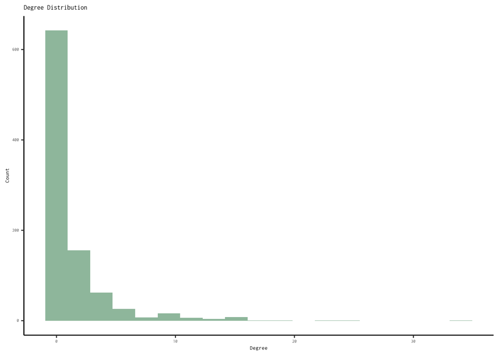

(a) Linear Scale

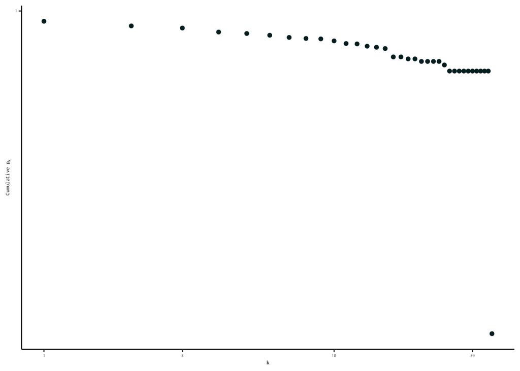

(b) Cumulative

Figure 2: Degree Distribution of Forest Bioeconomy Collaborations in SWINNO

```r
# Plot the degree distribution in linear scale
ggplot(degree_df, aes(x = degree)) +
    geom_histogram(fill = darkseagreen, bins = 19) +
    labs(title = "Degree Distribution", x = "Degree", y = "Count") +
    pjk_theme()

# Calculate the number of nodes with each degree
degree_counts <- table(degree_distribution)

# Create a data frame with the degree and count
degree_counts_df <- data.frame(
    degree = as.numeric(names(degree_counts)),
    count = as.numeric(degree_counts)
)

# Plot the  cdf degree distribution in log-log scale

cdf_df <- as.data.frame(1 - cumsum(degree.distribution(cleaned_g)))
cdf_df <- rownames_to_column(cdf_df, var = "k")
colnames(cdf_df) <- c("k", "cdf")
cdf_df$k <- as.numeric(cdf_df$k)


ggplot(cdf_df, aes(k, cdf)) +
    geom_point(color = darkgreen) +
    scale_x_log10() +
    scale_y_log10(breaks = c(1, 100)) +
    xlab("k") +
    ylab(expression(Cumulative ~ p[k])) +
    pjk_theme()
```

Neither subplot in Figure 2 suggests that the degree distribution of the forest bioeconomy collaborations network can be approximated by a binominal or poisson distribution. Further evidence that the network is not a random network.

#### Betweenness

**Calculate Betweeness and Find Bridge Nodes**

```r
ebs <- edge_betweenness(cleaned_g)

# Get the top edges with their betweenness scores as a data frame
top_between <- as_edgelist(cleaned_g)[ebs = head(sort(ebs, decreasing = TRUE)), ]
top_between_df <- data.frame(
    edges = paste(top_between[, 1], top_between[, 2], sep = " -- "),
    betweenness = head(sort(ebs, decreasing = TRUE), n = length(top_between))
)

# Print the data frame
top_between_df |>
    unique() |>
    gt() |>
    cols_label(edges = "Edge", betweenness = "Betweenness")
```

| Edge | Betweenness |
| --- | --- |
| Ikea -- KF | 392 |
| Acreo -- KTH | 300 |
| KTH -- Tekniska högskolan i Helsingfors | 296 |
| Stora (group) -- KTH | 286 |
| Ikea -- KF | 260 |
| Acreo -- KTH | 260 |
| KTH -- Tekniska högskolan i Helsingfors | 212 |
| KTH -- Tekniska högskolan i Helsingfors | 204 |
| Stora (group) -- KTH | 150 |

#### Clustering

**Calculate Clustering Coefficient**

```r
clustering_coeff <- transitivity(cleaned_g, type = "local")
avg_clustering_coeff <- transitivity(cleaned_g, type = "global")
```

## ToDo

Much. In addition to the questions posed in the introduction, the plan is to investigate the network dynamics. The first draft of this paper using data only until 2010 did not feature KTH as such a prominent node in the network. The reasons for this surge in importance are an intruiging avenue for further investigation. In addition, tying the network to recent research from political sciences on the disourse of the forest bioeconomy is intended.

## References

Barabási, A.-L., & Pósfai, M. (2016). *Network science*. Cambridge University Press.

Beland Lindahl, K., Sténs, A., Sandström, C., Johansson, J., Lidskog, R., Ranius, T., & Roberge, J.-M. (2015). The Swedish forestry model: More of everything? *Forest Policy and Economics*, *77*. https://doi.org/10.1016/j.forpol.2015.10.012

Bugge, M. M., Hansen, T., & Klitkou, A. (2016). What Is the Bioeconomy? A Review of the Literature. *Sustainability*, *8*(7), 691. https://doi.org/10.3390/su8070691

Högbom, L., Abbas, D., Armolaitis, K., Baders, E., Futter, M., Jansons, A., Jõgiste, K., Lazdins, A., Lukminė, D., Mustonen, M., Øistad, K., Poska, A., Rautio, P., Svensson, J., Vodde, F., Varnagirytė-Kabašinskienė, I., Weslien, J., Wilhelmsson, L., & Zute, D. (2021). Trilemma of Nordic to Implement UN Sustainable Development Goals. *Sustainability*, *13*(10), 5643. https://doi.org/10.3390/su13105643

Holmgren, S., Giurca, A., Johansson, J., Kanarp, C. S., Stenius, T., & Fischer, K. (2022). Whose transformation is this? Unpacking the “apparatus of capture” in Sweden’s bioeconomy. *Environmental Innovation and Societal Transitions*, *42*, 44–57. https://doi.org/10.1016/j.eist.2021.11.005

Sjöö, K., Taalbi, J., Kander, A., & Ljungberg, J. (2014). A Database of Swedish Innovations, 1970-2007. *Lund Papers in Economic History*, *General Issues*(133), 77.

Söderholm, K., Bergquist, A.-K., & Söderholm, P. (2017). The transition to chlorine free pulp revisited: Nordic heterogeneity in environmental regulation and R&D collaboration. *Journal of Cleaner Production*, *165*, 1328–1339. https://doi.org/10.1016/j.jclepro.2017.07.190

Taalbi, J. (2017). Development blocks in innovation networks. *Journal of Evolutionary Economics*, *27*(3), 461–501. https://doi.org/10.1007/s00191-017-0491-y